# Machine Learning Data Science

Dann Hekman

November 18, 2015

# Introduction and Study Design

This model was built for the Coursera Practical Machine Learning class project, part of [Data Science Specialization](https://www.coursera.org/specializations/jhudatascience) taught by Professors [Jeff Leek](https://github.com/jtleek), [Roger Peng](https://github.com/rdpeng), and [Brian Caffo](https://github.com/bcaffo).

Data come from sensors used while weightlifting, and we will use these sensors to predict if the particpants were using the excersize correctly (`classe='A'`) or doing one of 4 common mistakes (`classe = 'B', 'C', 'D', or 'E'`).

## Data Partitioning

This study uses separate training, validation, and testing datasets, with 20% of the data in the test set, 16% in the validation set, and 64% of the data in the training set.

```r
set.seed(1337)
allData  <- read.csv('./data/train.csv')
inTest   <- createDataPartition(y=allData$X,p=.2,list=FALSE)
testData <- allData[inTest,]
trainData<- allData[-inTest,]
inValid  <- createDataPartition(y=trainData$X,p=.2,list=FALSE) #.8*.2=16% of allData
validData<- trainData[inValid,]
trainData<- trainData[-inValid,]
```

## Data Preparation

To minimize overfitting to outliers, any variables that were 75% null, blank, or NA were removed from the training set.

```r
##Remove Columns where more than 75% are blank
trainData<-trainData[,sapply(trainData,function(x) (length(x[x != ""])>(0.75*nrow(trainData))))]
##Remove Columns where more than 75% are NA
trainData<-trainData[,sapply(trainData,function(x) (length(x[!is.na(x)])>(0.75*nrow(trainData))))]
```

# Exploratory Data Analysis

Three-dimensional scatter plots were constructed to explore the data. Each plot shows the spacial movement from the gyroscope from one of the 4 sensors.

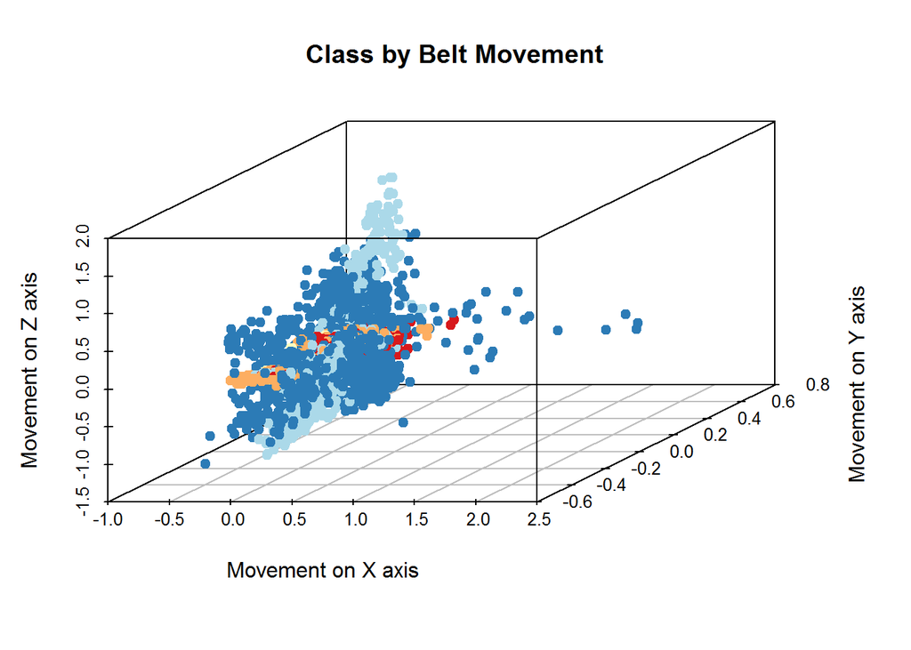

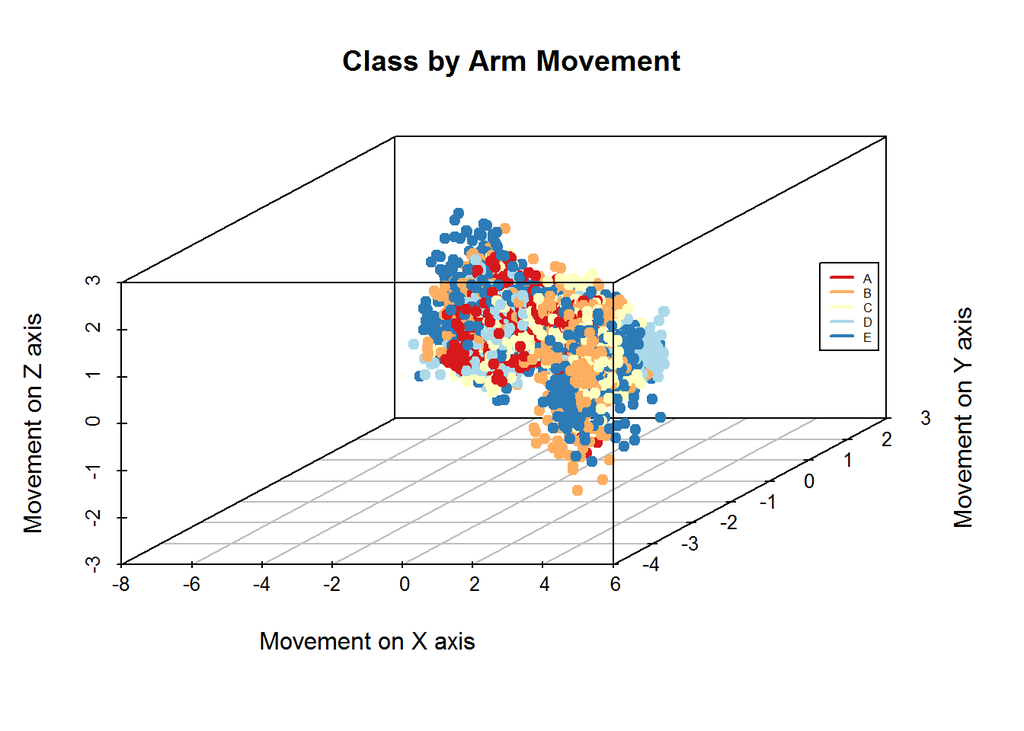

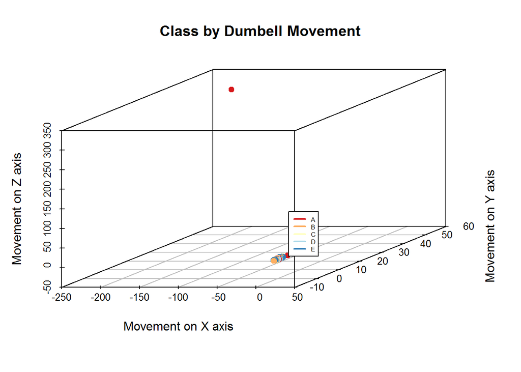

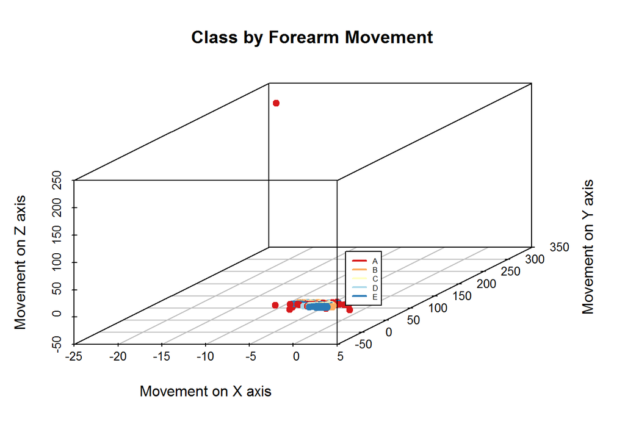

We can see from some of the graphs that are is at least one outlier in the dataset that may impact the model. Were I doing regression, this observation would need to be reviewed more thoroughly, but because I’m using trees, I decided not to worry about this particular observation

# Modeling

Models were evaluated on two key criteria:  
1. Speed. Due to technological constraints (having an older computer and limited time), I did not pursue the random forest model because it took too long to run and evaluate.  
2. Accuracy. Models were compared based on accuracy when run against the validation set.

## Model 1: Simple RPart Tree

Model 1 is an rpart tree using the `rpart` function and library.

```r
accuracy <- function(values,prediction){sum((prediction == values))/length(values)}
model1 <- rpart(classe~.,data=trainData,method="class")

data.frame(training_set = accuracy(trainData$classe,predict(model1,newdata=trainData,type="class")),
           validation_set = accuracy(validData$classe,predict(model1,newdata=validData,type="class")))
```

```
##   training_set validation_set
## 1    0.7539025      0.7515924
```

## Model 2: Simple CTree

Model 2 is another tree model, built using the `ctree` and `caret` libraries.

```r
model2 <- train(classe~.,data=trainData,method="ctree")
data.frame(training_set = accuracy(trainData$classe,predict(model2,newdata=trainData)),
         validation_set = accuracy(validData$classe,predict(model2,newdata=validData)))
```

```
##   training_set validation_set
## 1    0.9219497      0.8757962
```

## Model 3: CTree with Principal Component Analysis

Model 3 is also built with the `ctree` modeling library, but also uses `caret` functionality to apply principle component analysis as preprocessing.

```r
model3 <- train(classe~.,data=trainData,method="ctree", preProcess="pca")
data.frame(training_set = accuracy(trainData$classe,predict(model3,newdata=trainData)),
         validation_set = accuracy(validData$classe,predict(model3,newdata=validData)))
```

```
##   training_set validation_set
## 1    0.8660401      0.7761146
```

# Results

Of the 3 Models Evaluated, Model 2, CTree without PCA, performed the best on the validation set.

```r
bestModel <- model2
print(xtable(table(trainData$classe,predict(bestModel,newdata=trainData)),caption="Performance in Training Set"),type="html")
```

Performance in Training Set

|  | A | B | C | D | E |
| --- | --- | --- | --- | --- | --- |
| A | 3429 | 74 | 31 | 24 | 20 |
| B | 92 | 2201 | 66 | 26 | 52 |
| C | 33 | 106 | 1926 | 71 | 41 |
| D | 48 | 65 | 52 | 1850 | 39 |
| E | 20 | 64 | 24 | 32 | 2170 |

```r
print(xtable(table(testData$classe,predict(bestModel,newdata=testData,)),caption="Performance in Test Set"),type="html")
```

Performance in Test Set

|  | A | B | C | D | E |
| --- | --- | --- | --- | --- | --- |
| A | 1025 | 54 | 10 | 11 | 15 |
| B | 50 | 631 | 31 | 21 | 25 |
| C | 18 | 55 | 576 | 20 | 20 |
| D | 17 | 35 | 32 | 545 | 18 |
| E | 9 | 37 | 20 | 13 | 638 |

```r
print(xtable(data.frame(training_accuracy =
                 accuracy(trainData$classe,predict(bestModel,newdata=trainData)),
            validation_accuracy =
                 accuracy(validData$classe,predict(bestModel,newdata=validData)),
            testing_accuracy =
                 accuracy(testData$classe ,predict(bestModel,newdata=testData)))),
      type="html")
```

|  | training_accuracy | validation_accuracy | testing_accuracy |
| --- | --- | --- | --- |
| 1 | 0.92 | 0.88 | 0.87 |

# References

Data Generously provided by Velloso et al. Velloso, E.; Bulling, A.; Gellersen, H.; Ugulino, W.; Fuks, H. Qualitative Activity Recognition of Weight Lifting Exercises. Proceedings of 4th International Conference in Cooperation with SIGCHI (Augmented Human ’13) . Stuttgart, Germany: ACM SIGCHI, 2013.

Read more: http://groupware.les.inf.puc-rio.br/har#ixzz3sA3HLCEL